# Analisis_generico

# Definir directorio de trabajo

Aqui probablemente el codigo te dara problemas, porque queremos definir como directorio de trabajo la carpeta de COPLAS porque los archivos estan ahi. Como este Markdown esta dentro de un Proyecto con su carpeta asociada, R entiende que el directorio es ese (“…/Instar/implementaciones/instar_baza/scripts/git_Instar_baza”). Estrictamente hablando deberiamos escribir el codigo de manera que cuando llamemos a un archivo le demos el path apropiado (“…_validacion_datos_validacion_PLAGAS“). Pero tambien se puede definir el directorio de manera manual (Session > Set Working Directory > Choose Directory), y asi R si acepta que sea una carpeta distinta a donde esta el proyecto. Por mi las dos opciones valen, la que te sea mas facil :)

He definido el WD de manera manual. Definir como directorio la carpeta COPLAS_PLAGAS # Cargar paquetes

```r
#install.packages("lubridate")
library(lubridate) # Para las fechas
```

# DATOS INSTAR

## Importar datos INSTAR

- La tabla de datos se construye en excel y se guarda como .csv
- Se abre con procesador de texto, y se comprueba que la fecha está en formato mm-dd-yy
- Se guarda como .txt Las columnas que constituyen la tabla son: fecha, huevo, L1, L2, crisalida, radiacion, tmax, tmin, tmed y exergia.

TOMAMOS EL RODAL GR-023-008 (Sierra de Baza) COMO EJEMPLO

```r
INSTAR<-read.table("instar_bz008.txt", header=T, sep=",", dec=".")
INSTAR$fecha <-as.Date(INSTAR$fecha, format="%m-%d-%y")#aunque pongo formato mm/dd/yyyy se pone como yyyy-mm-dd
```

## Anadir biociclos al data.frame

```r
INSTAR$yday <- yday(INSTAR$fecha) # anadimos el dia del anio con el paquete lubridate
INSTAR$year <- year(INSTAR$fecha) # anadimos el anio con el paquete lubridate
INSTAR$biociclo <- NULL
#write.csv(INSTAR, file = "datos_instar_bz008.csv", row.names=FALSE, na="")
```

Aparece dos chunks para este proceso, uno para Baza y otro para Sierra Nevada, ya que tienen fechas de inicio diferentes.

```r
#Baza
subset_1993 <- subset(INSTAR, INSTAR$year==1993)
for(i in 1:length(subset_1993$yday)){
  ifelse(subset_1993$yday[i]<=79,
       subset_1993$biociclo[i] <- 1, subset_1993$biociclo[i] <- 2)
}

subset_1994 <- subset(INSTAR, INSTAR$year==1994)
for(i in 1:length(subset_1994$yday)){
  ifelse(subset_1994$yday[i]<=79,
       subset_1994$biociclo[i] <- 2, subset_1994$biociclo[i] <- 3)
}

subset_1995 <- subset(INSTAR, INSTAR$year==1995)
for(i in 1:length(subset_1995$yday)){
  ifelse(subset_1995$yday[i]<=79,
       subset_1995$biociclo[i] <- 3, subset_1995$biociclo[i] <- 4)
}

subset_1996 <- subset(INSTAR, INSTAR$year==1996)
for(i in 1:length(subset_1996$yday)){
  ifelse(subset_1996$yday[i]<=79,
       subset_1996$biociclo[i] <- 4, subset_1996$biociclo[i] <- 5)
}

subset_1997 <- subset(INSTAR, INSTAR$year==1997)
for(i in 1:length(subset_1997$yday)){
  ifelse(subset_1997$yday[i]<=79,
       subset_1997$biociclo[i] <- 5, subset_1997$biociclo[i] <- 6)
}

subset_1998 <- subset(INSTAR, INSTAR$year==1998)
for(i in 1:length(subset_1998$yday)){
  ifelse(subset_1998$yday[i]<=79,
       subset_1998$biociclo[i] <- 6, subset_1998$biociclo[i] <- 7)
}

subset_1999 <- subset(INSTAR, INSTAR$year==1999)
for(i in 1:length(subset_1999$yday)){
  ifelse(subset_1999$yday[i]<=79,
       subset_1999$biociclo[i] <- 7, subset_1999$biociclo[i] <- 8)
}

subset_2000 <- subset(INSTAR, INSTAR$year==2000)
for(i in 1:length(subset_2000$yday)){
  ifelse(subset_2000$yday[i]<=79,
       subset_2000$biociclo[i] <- 8, subset_2000$biociclo[i] <- 9)
}

subset_2001 <- subset(INSTAR, INSTAR$year==2001)
for(i in 1:length(subset_2001$yday)){
  ifelse(subset_2001$yday[i]<=79,
       subset_2001$biociclo[i] <- 9, subset_2001$biociclo[i] <- 10)
}

subset_2002 <- subset(INSTAR, INSTAR$year==2002)
for(i in 1:length(subset_2002$yday)){
  ifelse(subset_2002$yday[i]<=79,
       subset_2002$biociclo[i] <- 10, subset_2002$biociclo[i] <- 11)
}

subset_2003 <- subset(INSTAR, INSTAR$year==2003)
for(i in 1:length(subset_2003$yday)){
  ifelse(subset_2003$yday[i]<=79,
       subset_2003$biociclo[i] <- 11, subset_2003$biociclo[i] <- 12)
}

subset_2004 <- subset(INSTAR, INSTAR$year==2004)
for(i in 1:length(subset_2004$yday)){
  ifelse(subset_2004$yday[i]<=79,
       subset_2004$biociclo[i] <- 12, subset_2004$biociclo[i] <- 13)
}
subset_2005 <- subset(INSTAR, INSTAR$year==2005)
for(i in 1:length(subset_2005$yday)){
  ifelse(subset_2005$yday[i]<=79,
       subset_2005$biociclo[i] <- 13, subset_2005$biociclo[i] <- 14)
}

subset_2006 <- subset(INSTAR, INSTAR$year==2006)
for(i in 1:length(subset_2006$yday)){
  ifelse(subset_2006$yday[i]<=79,
       subset_2006$biociclo[i] <- 14, subset_2006$biociclo[i] <- 15)
}

subset_2007 <- subset(INSTAR, INSTAR$year==2007)
for(i in 1:length(subset_2007$yday)){
  ifelse(subset_2007$yday[i]<=79,
       subset_2007$biociclo[i] <- 15, subset_2007$biociclo[i] <- 16)
}

subset_2008 <- subset(INSTAR, INSTAR$year==2008)
for(i in 1:length(subset_2008$yday)){
  ifelse(subset_2008$yday[i]<=79,
       subset_2008$biociclo[i] <- 16, subset_2008$biociclo[i] <- 17)
}

subset_2009 <- subset(INSTAR, INSTAR$year==2009)
for(i in 1:length(subset_2009$yday)){
  ifelse(subset_2009$yday[i]<=79,
       subset_2009$biociclo[i] <- 17, subset_2009$biociclo[i] <- 18)
}

subset_2010 <- subset(INSTAR, INSTAR$year==2010)
for(i in 1:length(subset_2010$yday)){
  ifelse(subset_2010$yday[i]<=79,
       subset_2010$biociclo[i] <- 18, subset_2010$biociclo[i] <- 19)
}

subset_2011 <- subset(INSTAR, INSTAR$year==2011)
for(i in 1:length(subset_2011$yday)){
  ifelse(subset_2011$yday[i]<=79,
       subset_2011$biociclo[i] <- 19, subset_2011$biociclo[i] <- 20)
}

subset_2012 <- subset(INSTAR, INSTAR$year==2012)
for(i in 1:length(subset_2012$yday)){
  ifelse(subset_2012$yday[i]<=79,
       subset_2012$biociclo[i] <- 20, subset_2012$biociclo[i] <- 21)
}

subset_2013 <- subset(INSTAR, INSTAR$year==2013)
for(i in 1:length(subset_2013$yday)){
  ifelse(subset_2013$yday[i]<=79,
       subset_2013$biociclo[i] <- 21, subset_2013$biociclo[i] <- 22)
}

subset_2014 <- subset(INSTAR, INSTAR$year==2014)
for(i in 1:length(subset_2014$yday)){
  ifelse(subset_2014$yday[i]<=79,
       subset_2014$biociclo[i] <- 22, subset_2014$biociclo[i] <- 23)
}

INSTAR<- rbind(subset_1994, subset_1995, subset_1996, subset_1997, subset_1998, subset_1999, subset_2000, subset_2001, subset_2002, subset_2003, subset_2004, subset_2005, subset_2006, subset_2007, subset_2008, subset_2009, subset_2010, subset_2011, subset_2012, subset_2013, subset_2014) #Se quitan el primer y ultimo biociclo porque no estan completos

#QUITAR BIOCICLO 2 y 23(incompletos)
INSTAR<-INSTAR[!(INSTAR$biociclo=="2"),]
INSTAR<-INSTAR[!(INSTAR$biociclo=="23"),]
```

```r
#Sierra Nevada
subset_2001 <- subset(INSTAR, INSTAR$year==2001)
for(i in 1:length(subset_2001$yday)){
  ifelse(subset_2001$yday[i]<=79,
       subset_2001$biociclo[i] <- 1, subset_2001$biociclo[i] <- 2)
}

subset_2002 <- subset(INSTAR, INSTAR$year==2002)
for(i in 1:length(subset_2002$yday)){
  ifelse(subset_2002$yday[i]<=79,
       subset_2002$biociclo[i] <- 2, subset_2002$biociclo[i] <- 3)
}

subset_2003 <- subset(INSTAR, INSTAR$year==2003)
for(i in 1:length(subset_2003$yday)){
  ifelse(subset_2003$yday[i]<=79,
       subset_2003$biociclo[i] <- 3, subset_2003$biociclo[i] <- 4)
}

subset_2004 <- subset(INSTAR, INSTAR$year==2004)
for(i in 1:length(subset_2004$yday)){
  ifelse(subset_2004$yday[i]<=79,
       subset_2004$biociclo[i] <- 4, subset_2004$biociclo[i] <- 5)
}
subset_2005 <- subset(INSTAR, INSTAR$year==2005)
for(i in 1:length(subset_2005$yday)){
  ifelse(subset_2005$yday[i]<=79,
       subset_2005$biociclo[i] <- 5, subset_2005$biociclo[i] <- 6)
}

subset_2006 <- subset(INSTAR, INSTAR$year==2006)
for(i in 1:length(subset_2006$yday)){
  ifelse(subset_2006$yday[i]<=79,
       subset_2006$biociclo[i] <- 6, subset_2006$biociclo[i] <- 7)
}

subset_2007 <- subset(INSTAR, INSTAR$year==2007)
for(i in 1:length(subset_2007$yday)){
  ifelse(subset_2007$yday[i]<=79,
       subset_2007$biociclo[i] <- 7, subset_2007$biociclo[i] <- 8)
}

subset_2008 <- subset(INSTAR, INSTAR$year==2008)
for(i in 1:length(subset_2008$yday)){
  ifelse(subset_2008$yday[i]<=79,
       subset_2008$biociclo[i] <- 8, subset_2008$biociclo[i] <- 9)
}

subset_2009 <- subset(INSTAR, INSTAR$year==2009)
for(i in 1:length(subset_2009$yday)){
  ifelse(subset_2009$yday[i]<=79,
       subset_2009$biociclo[i] <- 9, subset_2009$biociclo[i] <- 10)
}

subset_2010 <- subset(INSTAR, INSTAR$year==2010)
for(i in 1:length(subset_2010$yday)){
  ifelse(subset_2010$yday[i]<=79,
       subset_2010$biociclo[i] <- 10, subset_2010$biociclo[i] <- 11)
}

subset_2011 <- subset(INSTAR, INSTAR$year==2011)
for(i in 1:length(subset_2011$yday)){
  ifelse(subset_2011$yday[i]<=79,
       subset_2011$biociclo[i] <- 11, subset_2011$biociclo[i] <- 12)
}

subset_2012 <- subset(INSTAR, INSTAR$year==2012)
for(i in 1:length(subset_2012$yday)){
  ifelse(subset_2012$yday[i]<=79,
       subset_2012$biociclo[i] <- 12, subset_2012$biociclo[i] <- 13)
}

subset_2013 <- subset(INSTAR, INSTAR$year==2013)
for(i in 1:length(subset_2013$yday)){
  ifelse(subset_2013$yday[i]<=79,
       subset_2013$biociclo[i] <- 13, subset_2013$biociclo[i] <- 14)
}

subset_2014 <- subset(INSTAR, INSTAR$year==2014)
for(i in 1:length(subset_2014$yday)){
  ifelse(subset_2014$yday[i]<=79,
       subset_2014$biociclo[i] <- 14, subset_2014$biociclo[i] <- 15)
}

INSTAR<- rbind(subset_2002, subset_2003, subset_2004, subset_2005, subset_2006, subset_2007, subset_2008, subset_2009, subset_2010, subset_2011, subset_2012, subset_2013)
```

## Agregacion INSTAR

Media del vigor y sumas (l1, l2 y l1+l2) por biociclo

```r
sum_l1<- aggregate(x = INSTAR$L1, by=list(biociclo=INSTAR$biociclo), FUN=sum, na.rm=TRUE)
names(sum_l1)[2] <- "sum_l1"

sum_l2<- aggregate(x = INSTAR$L2, by=list(biociclo=INSTAR$biociclo), FUN=sum, na.rm=TRUE)
names(sum_l2)[2] <- "sum_l2"

larvas<-cbind(sum_l1, sum_l2)
larvas<-larvas[-c(3)]
larvas$sum_l1l2=larvas[,2]+larvas[,3]

sum_huevo<- aggregate(x = INSTAR$huevo, by=list(biociclo=INSTAR$biociclo), FUN=sum, na.rm=TRUE)
names(sum_huevo)[2] <- "sum_huevo"

sum_crisalida<- aggregate(x = INSTAR$crisalida, by=list(biociclo=INSTAR$biociclo), FUN=sum, na.rm=TRUE)
names(sum_crisalida)[2] <- "sum_crisalida"

avg_exergia<-aggregate(INSTAR$exergia, by=list(biociclo=INSTAR$biociclo), FUN=mean, na.rm=TRUE)
names(avg_exergia)[2] <- "avg_exergia"



agreg_INSTAR <- cbind(larvas,avg_exergia, sum_crisalida, sum_huevo)
agreg_INSTAR_biociclo <- agreg_INSTAR[ -c(5, 7, 9) ]

#write.csv(agreg_INSTAR_biociclo,"agreg_INSTAR_bz008_biociclo.csv",row.names=FALSE, na="")
```

## Ln INSTAR (l1, l2 y l1+l2)

*Update: En la reunión del 9 de septiembre se llegó a la conclusión de que no era necesario transformar las variables.

Se agrega una columna a la tabla ‘Agreg_INSTAR_xxxxx_biociclo’ con el resultado del Ln de cada columna referente a Larvas (sum_l1, sum_l2, sum_l1l2)

# DATOS COPLAS

## Importar datos COPLAS

```r
COPLAS<-read.csv("zona_baza.csv", header=TRUE, sep=",")
names(COPLAS)[1] <- "RODAL"
```

Llamamos a cada rodal como los tres ultimos numeros de su codigo GRxxxxxx Activar el rodal necesario para el análisis.

```r
#rodal<-subset(COPLAS, RODAL == "GR000006")
rodal<-subset(COPLAS, RODAL == "GR023008")
#rodal<-subset(COPLAS, RODAL == "GR023012")
#rodal<-subset(COPLAS, RODAL == "GR023015")
#rodal<-subset(COPLAS, RODAL == "GR023017")
#rodal<-subset(COPLAS, RODAL == "GR023021")

#rodal<-subset(COPLAS, RODAL == "GR000030")
#rodal<-subset(COPLAS, RODAL == "GR134018")
#rodal<-subset(COPLAS, RODAL == "GR134020")
#rodal<-subset(COPLAS, RODAL == "GR134021")

#Eliminar primer y ultimo año porque en Instar no teneos datos de ese año completo.
rodal<-rodal[-c(1,2, 23),]
```

## Definir biociclo COPLAS (opcional)

```r
rodal$biociclo <- 3:22 #Sierra de Baza
#rodal$biociclo <- 1:15 #Sierra Nevada
```

## Crear una tabla unica en la que tengamos los datos agregados de Instar y los datos de COPLAS

```r
COPLAS_INSTAR<-merge.data.frame(agreg_INSTAR_biociclo, rodal, by.x = "biociclo")
COPLAS_INSTAR<-COPLAS_INSTAR[-c(8)] #Eliminar la columna con el nombre del rodal
```

# VALIDACION EXTERNA

```r
library(graphics)
library(ggplot2)
```

## glm [avg_exergia, sum_l1, sum_l2, sum_l1l2 vs COPLAS]

*Se realizara, finalmente, GLM que analicen la relacion entre las variables de Instar (Exergia, sumL1, sumL2 y sumL1L2) y COPLAS. La distribucion es de Poisson.*

Una alternativa a la transformacion de la variable respuesta y a la falta de normalidad es el uso de los modelos linales generalizados. Los GLM son una extension de los modelos lineales que permiten utilizar distribuciones no normales de lso errores (Poisson, como en este caso) y varianzas no constantes.

Los modelos Poisoon se utilizan generalmente para representar datos de conteo. El uso de modelos lineales no sera adecuado ante datos de conteo por las siguientes razones: - El modelo lineal podra predecir valores negativos de la variable respuesta. - La varianza de la variable respuesta aumnetara probablemente a medida que aumenta la media (varianza no constante). - Los errores no estan normalmente distribuidos. - Los ceros son dificiles de manejar en transformaciones de la variable respuesta.

Comprobar dispersion. ?Como se hace? “Overdispersed Poisson occurs when sd >> mean”

### Asunciones y modelo de regresion lineal

#### POISSON

Observar: - Overdispersion

**EXERGIA**

```r
cor(COPLAS_INSTAR$avg_exergia, COPLAS_INSTAR$GRADO.REVISADO)
```

```
## [1] -0.3364764
```

```r
reg_exergia <- glm(COPLAS_INSTAR$avg_exergia ~ COPLAS_INSTAR$GRADO.REVISADO, family = poisson(link="log"))
summary.glm(reg_exergia)
```

```
##
## Call:
## glm(formula = COPLAS_INSTAR$avg_exergia ~ COPLAS_INSTAR$GRADO.REVISADO,
##     family = poisson(link = "log"))
##
## Deviance Residuals:
##      Min        1Q    Median        3Q       Max
## -0.27835  -0.07260   0.01968   0.09800   0.15847
##
## Coefficients:
##                               Estimate Std. Error z value Pr(>|z|)
## (Intercept)                   4.256937   0.040152  106.02   <2e-16 ***
## COPLAS_INSTAR$GRADO.REVISADO -0.004702   0.031302   -0.15    0.881
## ---
## Signif. codes:  0 '***' 0.001 '**' 0.01 '*' 0.05 '.' 0.1 ' ' 1
##
## (Dispersion parameter for poisson family taken to be 1)
##
##     Null deviance: 0.19967  on 11  degrees of freedom
## Residual deviance: 0.17703  on 10  degrees of freedom
## AIC: Inf
##
## Number of Fisher Scoring iterations: 3
```

*“The first two lines tell us which model has been fitted, which is handy if you save the output into a word processor document. Basic numerical information on the residuals is also provided, although in Section 9.8 we present more useful graphical tools that can be used for the model validation process. The estimated intercept and slope are 4.31 and –0.000106, respectively. Keep in mind that distance to the park is expressed in metres. To avoid parameter estimates with lots of zeros, you could (and perhaps should) express it in kilometres, as it will save some ink when presenting the estimated slope on paper. We also get a z-statistic and corresponding p-value for testing the null hypothesis that the slope (and intercept) is equal to 0 and an AIC, which can be used for model selection. The z-statistic is used because we know the variance. In a Gaussian model, the variance is estimated as well, and therefore, a t-statistic is used.”* *“The smaller the residual deviance, the better is the model.”*

```r
# Mirar overdispersion = residual deviance/df
3.8162/18
```

```
## [1] 0.2120111
```

```r
## Pearson residuals
(resid(reg_exergia, type="pearson"))^2
```

```
##            1            2            3            4            5
## 2.201015e-02 9.867622e-06 1.093094e-02 9.228982e-03 1.170614e-03
##            6            7            8            9           10
## 1.238381e-02 7.662320e-02 1.314099e-03 1.188513e-02 1.962077e-03
##           11           12
## 2.527036e-02 3.636936e-03
```

```r
(1.51+0.79+0.58+0.003+0.34+0.091+0.41+0.08+0.001+0.01+0.0022+0.003+0.09+0.049+0.149+0.0057+0.067+0.011+0.0021+0.0015) / (18 - (1+1)) #=0.26
```

```
## [1] 0.2622188
```

```r
# Mirar explained deviance
(100*(3.8163-3.8162))/3.8163
```

```
## [1] 0.002620339
```

```r
# AIC
AIC(reg_exergia)
```

```
## [1] Inf
```

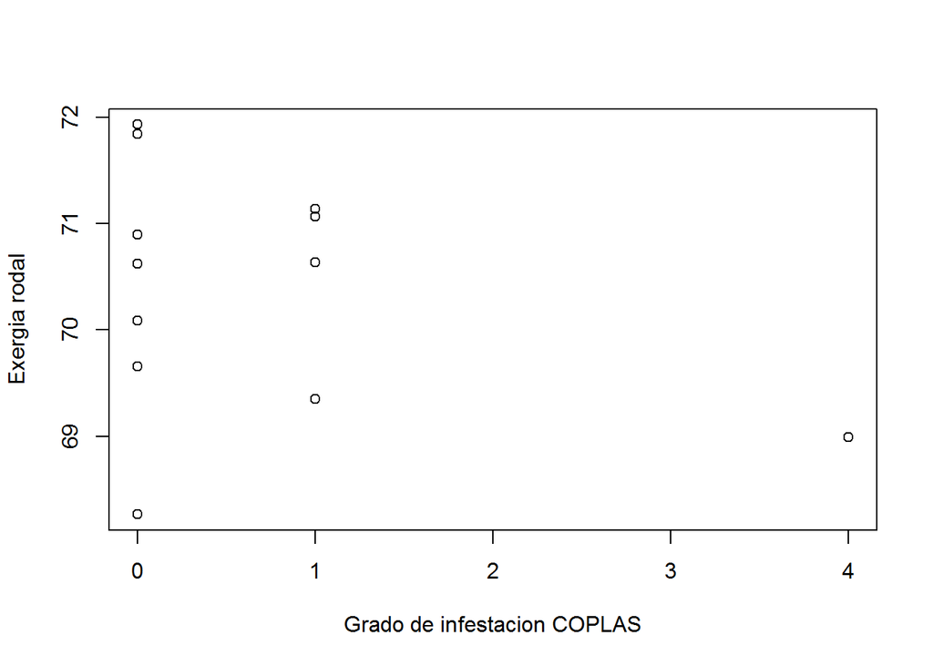

```r
plot(COPLAS_INSTAR$avg_exergia ~ COPLAS_INSTAR$GRADO.REVISADO, xlab="Grado de infestacion COPLAS", ylab = "Exergia rodal")
```

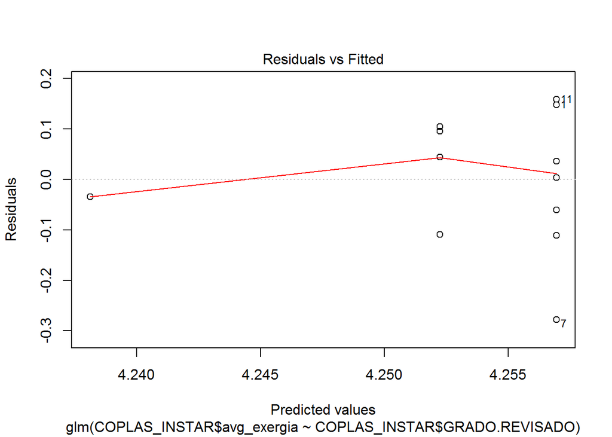

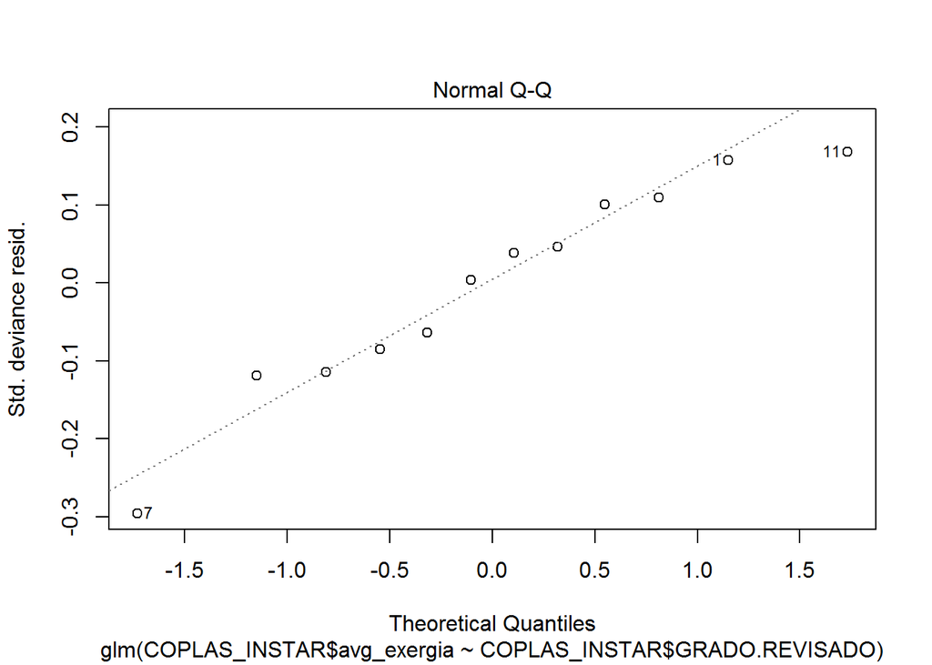

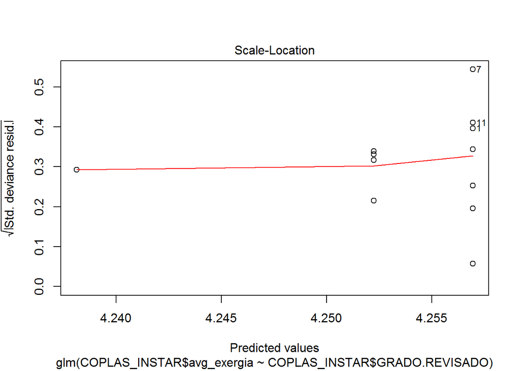

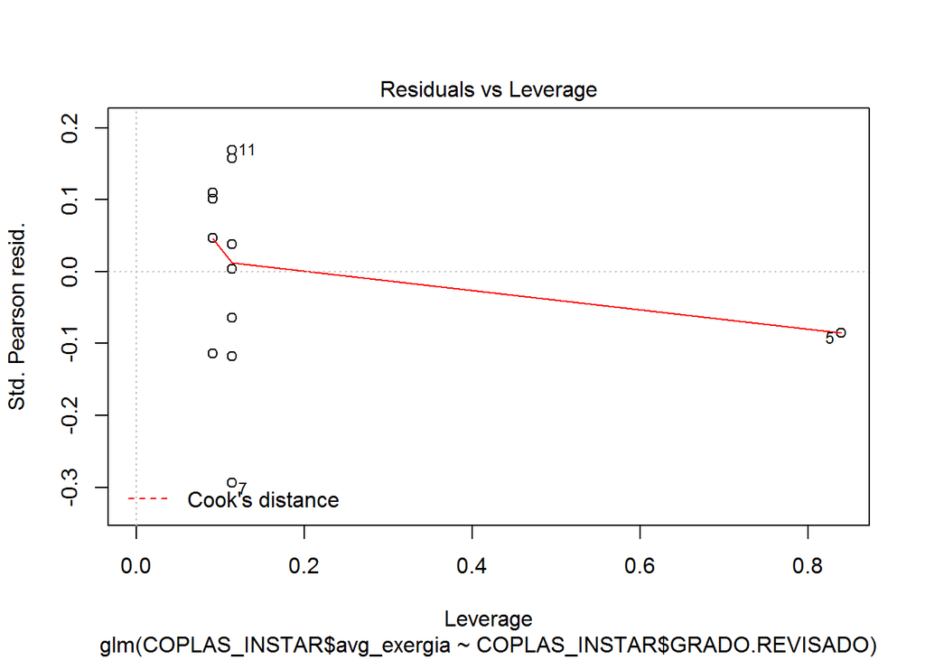

```r
plot(reg_exergia)
```

```r
dev.off()
```

**L1**

```r
cor(COPLAS_INSTAR$sum_l1, COPLAS_INSTAR$GRADO.REVISADO)
```

```
## [1] 0.2814033
```

```r
reg_L1 <- glm(COPLAS_INSTAR$sum_l1 ~ COPLAS_INSTAR$GRADO.REVISADO, family = poisson(link="log"))
summary.glm(reg_L1)
```

```
##
## Call:
## glm(formula = COPLAS_INSTAR$sum_l1 ~ COPLAS_INSTAR$GRADO.REVISADO,
##     family = poisson(link = "log"))
##
## Deviance Residuals:
##     Min       1Q   Median       3Q      Max
## -2932.3   -927.2    439.2    806.6   1088.3
##
## Coefficients:
##                               Estimate Std. Error z value Pr(>|z|)
## (Intercept)                  1.666e+01  8.035e-05  207359   <2e-16 ***
## COPLAS_INSTAR$GRADO.REVISADO 6.353e-02  5.706e-05    1113   <2e-16 ***
## ---
## Signif. codes:  0 '***' 0.001 '**' 0.01 '*' 0.05 '.' 0.1 ' ' 1
##
## (Dispersion parameter for poisson family taken to be 1)
##
##     Null deviance: 18039311  on 11  degrees of freedom
## Residual deviance: 16858780  on 10  degrees of freedom
## AIC: 16859006
##
## Number of Fisher Scoring iterations: 4
```

```r
#Mirar overdispersion
49182818/18
```

```
## [1] 2732379
```

Sea cual sea la formula que se use va a salir un valor **MUY ALTO**. Decimos que hay overdisp.?? Hacemos quasipoisson:

```r
reg_L1_qpois <- glm(COPLAS_INSTAR$sum_l1 ~ COPLAS_INSTAR$GRADO.REVISADO, family = quasipoisson)
summary(reg_L1_qpois)
```

```
##
## Call:
## glm(formula = COPLAS_INSTAR$sum_l1 ~ COPLAS_INSTAR$GRADO.REVISADO,
##     family = quasipoisson)
##
## Deviance Residuals:
##     Min       1Q   Median       3Q      Max
## -2932.3   -927.2    439.2    806.6   1088.3
##
## Coefficients:
##                              Estimate Std. Error t value Pr(>|t|)
## (Intercept)                  16.66233    0.09783 170.314   <2e-16 ***
## COPLAS_INSTAR$GRADO.REVISADO  0.06353    0.06947   0.915    0.382
## ---
## Signif. codes:  0 '***' 0.001 '**' 0.01 '*' 0.05 '.' 0.1 ' ' 1
##
## (Dispersion parameter for quasipoisson family taken to be 1482333)
##
##     Null deviance: 18039311  on 11  degrees of freedom
## Residual deviance: 16858780  on 10  degrees of freedom
## AIC: NA
##
## Number of Fisher Scoring iterations: 4
```

```r
#Mirar explained deviance
(100*(53589882-49182818))/53589882#=8.223687
```

```
## [1] 8.223687
```

```r
#AIC
AIC(reg_L1_qpois)#NA
```

```
## [1] NA
```

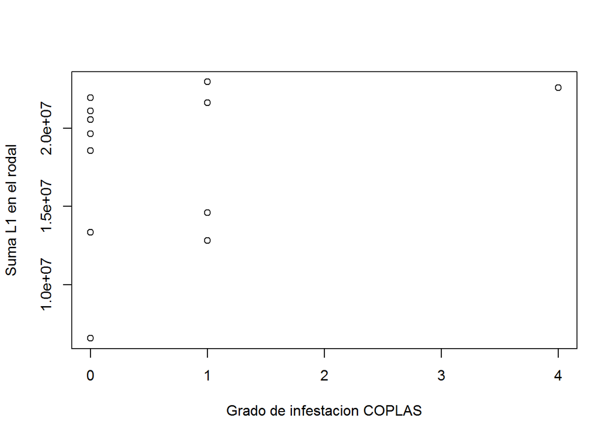

```r
#plots
plot(COPLAS_INSTAR$sum_l1 ~ COPLAS_INSTAR$GRADO.REVISADO, xlab="Grado de infestacion COPLAS", ylab = "Suma L1 en el rodal")
```

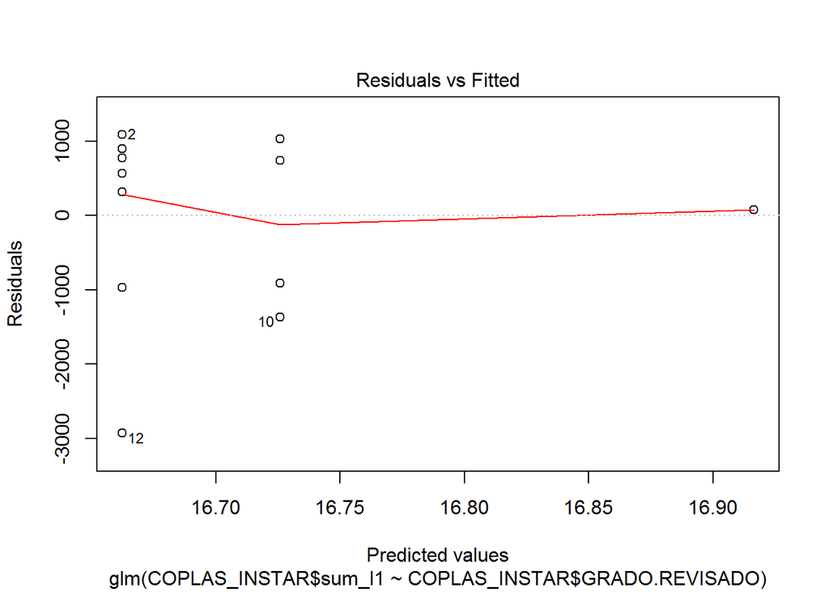

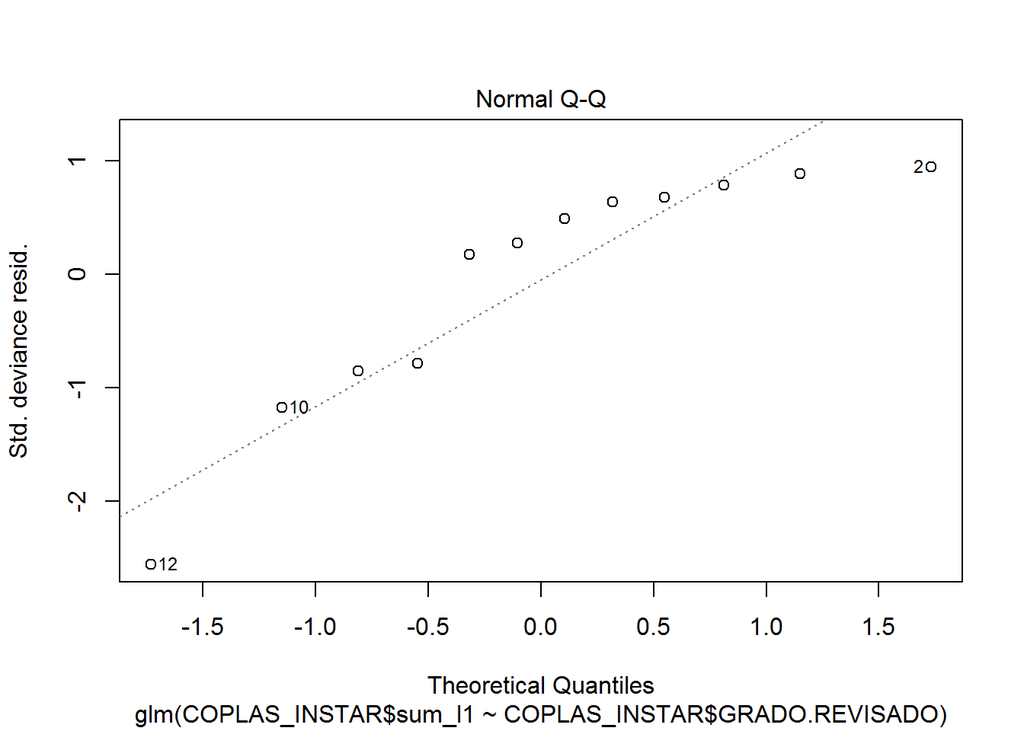

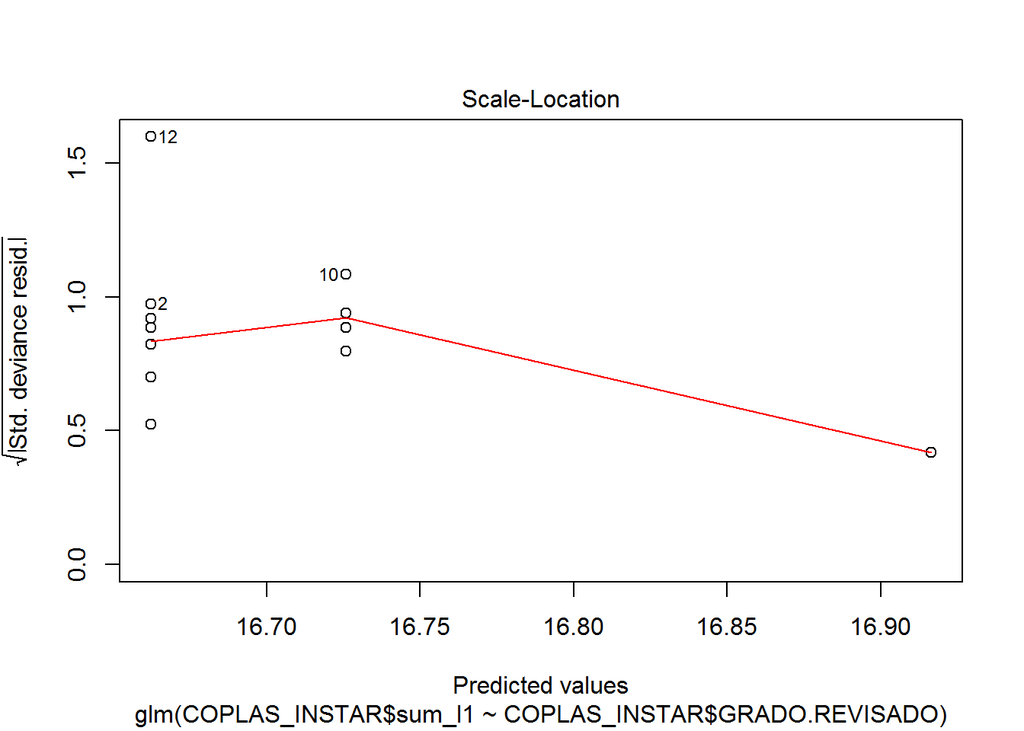

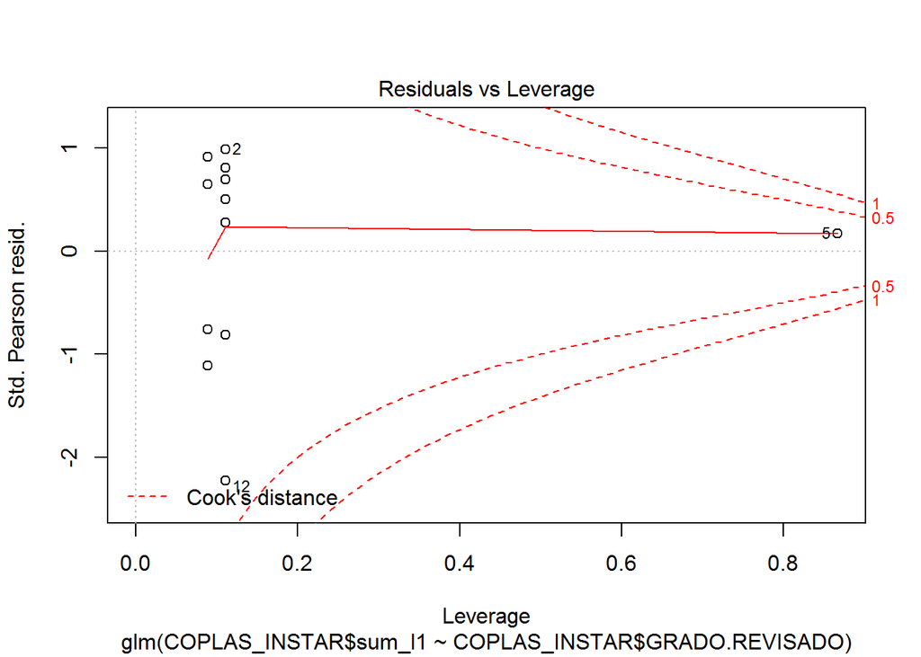

```r
plot(reg_L1_qpois)
```

```r
dev.off()
```

**L2**

```r
cor(COPLAS_INSTAR$sum_l2, COPLAS_INSTAR$GRADO.REVISADO)
```

```
## [1] 0.320123
```

```r
reg_L2 <- glm(COPLAS_INSTAR$sum_l2 ~ COPLAS_INSTAR$GRADO.REVISADO, family = poisson(link="log"))
summary.glm(reg_L2)
```

```
##
## Call:
## glm(formula = COPLAS_INSTAR$sum_l2 ~ COPLAS_INSTAR$GRADO.REVISADO,
##     family = poisson(link = "log"))
##
## Deviance Residuals:
##     Min       1Q   Median       3Q      Max
## -1670.5  -1287.8    378.8    733.6   1132.7
##
## Coefficients:
##                               Estimate Std. Error z value Pr(>|z|)
## (Intercept)                  1.648e+01  8.810e-05  187000   <2e-16 ***
## COPLAS_INSTAR$GRADO.REVISADO 7.259e-02  6.179e-05    1175   <2e-16 ***
## ---
## Signif. codes:  0 '***' 0.001 '**' 0.01 '*' 0.05 '.' 0.1 ' ' 1
##
## (Dispersion parameter for poisson family taken to be 1)
##
##     Null deviance: 14406686  on 11  degrees of freedom
## Residual deviance: 13101153  on 10  degrees of freedom
## AIC: 13101377
##
## Number of Fisher Scoring iterations: 4
```

```r
#Mirar overdispersion
26968257/18
```

```
## [1] 1498237
```

```r
reg_L2_qpois <- glm(COPLAS_INSTAR$sum_l2 ~ COPLAS_INSTAR$GRADO.REVISADO, family = quasipoisson)
summary.glm(reg_L2_qpois)
```

```
##
## Call:
## glm(formula = COPLAS_INSTAR$sum_l2 ~ COPLAS_INSTAR$GRADO.REVISADO,
##     family = quasipoisson)
##
## Deviance Residuals:
##     Min       1Q   Median       3Q      Max
## -1670.5  -1287.8    378.8    733.6   1132.7
##
## Coefficients:
##                              Estimate Std. Error t value Pr(>|t|)
## (Intercept)                  16.47520    0.09756 168.880   <2e-16 ***
## COPLAS_INSTAR$GRADO.REVISADO  0.07259    0.06842   1.061    0.314
## ---
## Signif. codes:  0 '***' 0.001 '**' 0.01 '*' 0.05 '.' 0.1 ' ' 1
##
## (Dispersion parameter for quasipoisson family taken to be 1226104)
##
##     Null deviance: 14406686  on 11  degrees of freedom
## Residual deviance: 13101153  on 10  degrees of freedom
## AIC: NA
##
## Number of Fisher Scoring iterations: 4
```

```r
#Dispersion segun quasipoison=1402424

#Mirar explained deviance
(100*(26968257-29317185))/26968257#=-8.709973
```

```
## [1] -8.709973
```

```r
#AIC
AIC(reg_L2_qpois)#NA
```

```
## [1] NA
```

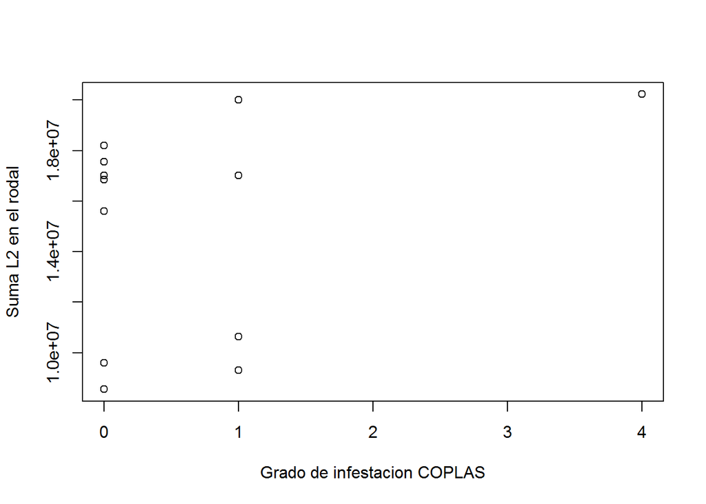

```r
#plots
plot(COPLAS_INSTAR$sum_l2 ~ COPLAS_INSTAR$GRADO.REVISADO, xlab="Grado de infestacion COPLAS", ylab = "Suma L2 en el rodal")
```